# Species lists with abundance data and biodiversity metrics

## Introduction - a simple example

I’m going to develop examples first shown in our Wednesday class on February 13th.

I was creating example “plant communities” using simply a typed letter to indicate an individual plants. So “A A A A A A” represents six individuals of species A. Then “B B B B B B” represents six individuals of a new species, B.

We can do this by creating a character variable, with multiple entries.

```r
one=c("A","A","A","A","A","A","B","B","B","B","B","B","C","C","C","C","C","C","D","E","F","G","H")
one
```

```
 [1] "A" "A" "A" "A" "A" "A" "B" "B" "B" "B" "B" "B" "C" "C" "C" "C" "C" "C" "D" "E"
[21] "F" "G" "H"
```

```r
length(one)
```

```
[1] 23
```

I asked for the variable length, which is 23. That tells us that there are 23 individuals in the sample.

```r
#Now we want to figure out something about abundances within species. Let's figure out, simply by counting,  how many individuals there are of each species. This is a measure of the abundance of each species. For this, we use the function "count" which is in a package called PLYR, which we must first load. Once that's done,  we create a new variable which has the count of each species
library(plyr)
one
```

```
 [1] "A" "A" "A" "A" "A" "A" "B" "B" "B" "B" "B" "B" "C" "C" "C" "C" "C" "C" "D" "E"
[21] "F" "G" "H"
```

```r
one.ab=count(one)
one.ab
```

| x | freq |
| --- | --- |
| A | 6 |
| B | 6 |
| C | 6 |
| D | 1 |
| E | 1 |
| F | 1 |
| G | 1 |
| H | 1 |

```r
class(one.ab)
```

```
[1] "data.frame"
```

```r
length(one.ab)
```

```
[1] 2
```

```r
#We might also want to get a list of species, and the length of that list (which is species richness).
one.u=unique(one)
one.u
```

```
[1] "A" "B" "C" "D" "E" "F" "G" "H"
```

```r
length(one.u)
```

```
[1] 8
```

```r
attributes(one.ab)
```

```
$names
[1] "x"    "freq"

$class
[1] "data.frame"

$row.names
[1] 1 2 3 4 5 6 7 8
```

```r
#But before we do the combining, we must add a variable to allow keeping track of which sample is which
one.ab=data.frame("one", one.ab)
one.ab
```

| X.one. | x | freq |
| --- | --- | --- |
| one | A | 6 |
| one | B | 6 |
| one | C | 6 |
| one | D | 1 |
| one | E | 1 |
| one | F | 1 |
| one | G | 1 |
| one | H | 1 |

```r
#This added a first column with every row populated by the string variable "one"
#Let's also re-name columns. Later, our analyses of species richenss will need specifically named variables.
names(one.ab)<-c("ListID", "SpeciesID", "Freq")
one.ab
```

| ListID | SpeciesID | Freq |
| --- | --- | --- |
| one | A | 6 |
| one | B | 6 |
| one | C | 6 |
| one | D | 1 |
| one | E | 1 |
| one | F | 1 |
| one | G | 1 |
| one | H | 1 |

Now let’s do that for another sample:

```r
three=c("A","A","A","A","A","A","B","B","B","B","B","B","B","C","C","C","C","C","C","C","D","E","F","G","Q")
three.ab=count(three)
three.ab
```

| x | freq |
| --- | --- |
| A | 6 |
| B | 7 |
| C | 7 |
| D | 1 |
| E | 1 |
| F | 1 |
| G | 1 |
| Q | 1 |

```r
#We might also want to get a list of species, and the length of that list (which is species richness).
three.u=unique(three)
three.u
```

```
[1] "A" "B" "C" "D" "E" "F" "G" "Q"
```

```r
length(three.u)
```

```
[1] 8
```

```r
#We can combine two files and compare them.
#Once again, let's add a variable to allow keeping track of which sample is which
three.ab=data.frame("three", three.ab)
three.ab
```

| X.three. | x | freq |
| --- | --- | --- |
| three | A | 6 |
| three | B | 7 |
| three | C | 7 |
| three | D | 1 |
| three | E | 1 |
| three | F | 1 |
| three | G | 1 |
| three | Q | 1 |

```r
names(three.ab)<-c("ListID", "SpeciesID", "Freq")
#And then combine the two variables into one
ab=rbind(one.ab, three.ab)
ab
```

| ListID | SpeciesID | Freq |
| --- | --- | --- |
| one | A | 6 |
| one | B | 6 |
| one | C | 6 |
| one | D | 1 |
| one | E | 1 |
| one | F | 1 |
| one | G | 1 |
| one | H | 1 |
| three | A | 6 |
| three | B | 7 |

[output cut: 6 more lines]

```r
dim(ab)
```

```
[1] 16  3
```

```r
#A powerful function in LABDSV converts this list of sample IDs, species and site-specific abundances into a matrix in which species names are column headings, and row names are samples. To do this, it creates a master list of all species in all samples. A matrix like this is useful for quantifying multiple aspects of biodiversity -- alpha and beta and gamma.
#So be sure to load the LABDSV package
library(labdsv)
abundance<-matrify(ab)
abundance
```

|  | A | B | C | D | E | F | G | H | Q |
| --- | --- | --- | --- | --- | --- | --- | --- | --- | --- |
| one | 6 | 6 | 6 | 1 | 1 | 1 | 1 | 1 | 0 |
| three | 6 | 7 | 7 | 1 | 1 | 1 | 1 | 0 | 1 |

```r
#If we look at the dimensions of this matrix, what does it mean? What is 2? What is 9?
dim(abundance)
```

```
[1] 2 9
```

## Matrix Power! Get a diversity index

Shannon-Weaver Diversity Index (H), possibly familiar from ecology or conservation biology classes, examines each species for the proportion of individuals that it contributes to the total individuals of all species in the sample (Pi).

If S is the total number of species in the transect (i.e., the species richness), Diversity, H = - SUM OVER species 1 to species i(Pi)*(ln(Pi)) (NOTE: “ln” is the natural logarithm and i refers to the ith species)

As an example, let’s return to the data above, where N total = 23 individuals:

```r
one
```

```
 [1] "A" "A" "A" "A" "A" "A" "B" "B" "B" "B" "B" "B" "C" "C" "C" "C" "C" "C" "D" "E"
[21] "F" "G" "H"
```

```r
length(one)
```

```
[1] 23
```

where N total = 23 individuals

Let Ni be the number of individuals of any given species, and Pi = Ni/Ntotal:

Species Ni Pi ln(Pi) Pi * ln(Pi) A 6 6/23 = 0.26 -1.34 -0.35 B 6 6/23 = 0.26 -1.34 -0.35 C 6 6/23 = 0.26 -1.34 -0.35 D 1 1/23 = 0.045 -3.13 -0.136 E 1 1/23 = 0.045 -3.13 -0.136 F 1 1/23 = 0.045 -3.13 -0.136 G 1 1/23 = 0.045 -3.13 -0.136 H 1 1/23 = 0.045 -3.13 -0.136 Q 0 0/23 = 0 0 0 H = -(-1.73)

You can try doing a similar calculation for Sample “three” and then compare to the values obtained from R using the VEGAN package

```r
library(vegan)
abundance
```

[output not shown]

```r
shannon<-diversity(abundance, index = "shannon")
shannon
```

[output not shown]

Another measure of diversity, Simpson’s index. There are actually a lot of different versions of Simpsons index, all roughly based on the likelihood that any two randomly encountered individuals are the same species.

In the package vegan, it is calculated as

D = 1 - Sum(p^2)

where p = n/N

where each n refers to the number of organisms of that particular species and N refers to the number of organisms of all species

Species ni p=n/N p^2  
A 6 6/23=0.26 0.068 B 6 6/23=0.26 0.068 C 6 6/23=0.26 0.068 D 1 1/23=0.043 0.00189 E 1 1/23=0.043 0.00189 F 1 1/23=0.043 0.00189 G 1 1/23=0.043 0.00189 H 1 1/23=0.043 0.00189 Q 0 0

```
            SUM         0.214
```

D = 1 - Sum(p^2) = 0.786

```r
abundance
```

|  | A | B | C | D | E | F | G | H | Q |
| --- | --- | --- | --- | --- | --- | --- | --- | --- | --- |
| one | 6 | 6 | 6 | 1 | 1 | 1 | 1 | 1 | 0 |
| three | 6 | 7 | 7 | 1 | 1 | 1 | 1 | 0 | 1 |

```r
simpson<-diversity(abundance, index = "simpson")
simpson
```

```
      one     three
0.7863894 0.7776000
```

```r
#We need to add more samples if we want to move toward making multiple pairwise comparisons
two=c("A","A","A","A","A","A","B","B","B","B","B","B","B","B","C","C","C","C","C","C","D","D","D","D","D","D","D","E","F","E","E","E","E","E","F","F","F","F","F","F","F","F","F","G","G","G","G","G","G","H","H","H","H","H","H","H","H")
five=c("A","A","A","A","A","A","B","B","B","B","B","B","B","D","D","D","D","D","D","D","J","K","L","M","N")
#Here are two additional samples named "two" and "five"
#By adding to this chunk of code (and running it), see if you can add to the output above to obtain similar data
two.ab=count(two)
two.ab
```

| x | freq |
| --- | --- |
| A | 6 |
| B | 8 |
| C | 6 |
| D | 7 |
| E | 6 |
| F | 10 |
| G | 6 |
| H | 8 |

```r
#We might also want to get a list of species, and the length of that list (which is species richness).
two.u=unique(two)
two.u
```

```
[1] "A" "B" "C" "D" "E" "F" "G" "H"
```

```r
length(two.u)
```

```
[1] 8
```

```r
five.ab=count(five)
five.ab
```

| x | freq |
| --- | --- |
| A | 6 |
| B | 7 |
| D | 7 |
| J | 1 |
| K | 1 |
| L | 1 |
| M | 1 |
| N | 1 |

```r
#We might also want to get a list of species, and the length of that list (which is species richness).
five.u=unique(five)
five.u
```

```
[1] "A" "B" "D" "J" "K" "L" "M" "N"
```

```r
length(five.u)
```

```
[1] 8
```

```r
#Let's add more data so we can continue to delve into what can be donetwo.ab
#Repeating what we did earlier, to process these lists so that we can incorporate them into an abundance matrix
two.ab=data.frame("two", two.ab)
two.ab
```

| X.two. | x | freq |
| --- | --- | --- |
| two | A | 6 |
| two | B | 8 |
| two | C | 6 |
| two | D | 7 |
| two | E | 6 |
| two | F | 10 |
| two | G | 6 |
| two | H | 8 |

```r
five.ab=data.frame("five", five.ab)
five.ab
```

| X.five. | x | freq |
| --- | --- | --- |
| five | A | 6 |
| five | B | 7 |
| five | D | 7 |
| five | J | 1 |
| five | K | 1 |
| five | L | 1 |
| five | M | 1 |
| five | N | 1 |

```r
names(two.ab)<-c("ListID", "SpeciesID", "Freq")
names(five.ab)<-c("ListID", "SpeciesID", "Freq")
one.ab
```

| ListID | SpeciesID | Freq |
| --- | --- | --- |
| one | A | 6 |
| one | B | 6 |
| one | C | 6 |
| one | D | 1 |
| one | E | 1 |
| one | F | 1 |
| one | G | 1 |
| one | H | 1 |

```r
three.ab
```

| ListID | SpeciesID | Freq |
| --- | --- | --- |
| three | A | 6 |
| three | B | 7 |
| three | C | 7 |
| three | D | 1 |
| three | E | 1 |
| three | F | 1 |
| three | G | 1 |
| three | Q | 1 |

```r
two.ab
```

| ListID | SpeciesID | Freq |
| --- | --- | --- |
| two | A | 6 |
| two | B | 8 |
| two | C | 6 |
| two | D | 7 |
| two | E | 6 |
| two | F | 10 |
| two | G | 6 |
| two | H | 8 |

```r
five.ab
```

| ListID | SpeciesID | Freq |
| --- | --- | --- |
| five | A | 6 |
| five | B | 7 |
| five | D | 7 |
| five | J | 1 |
| five | K | 1 |
| five | L | 1 |
| five | M | 1 |
| five | N | 1 |

```r
ab=rbind(one.ab, three.ab, two.ab, five.ab)
ab
```

| ListID | SpeciesID | Freq |
| --- | --- | --- |
| one | A | 6 |
| one | B | 6 |
| one | C | 6 |
| one | D | 1 |
| one | E | 1 |
| one | F | 1 |
| one | G | 1 |
| one | H | 1 |
| three | A | 6 |
| three | B | 7 |

[output cut: 22 more lines]

```r
dim(ab)
```

```
[1] 32  3
```

```r
#ab<-ab[,2:4]
abundance<-matrify(ab)
abundance
```

|  | A | B | C | D | E | F | G | H | Q | J | K | L | M | N |
| --- | --- | --- | --- | --- | --- | --- | --- | --- | --- | --- | --- | --- | --- | --- |
| one | 6 | 6 | 6 | 1 | 1 | 1 | 1 | 1 | 0 | 0 | 0 | 0 | 0 | 0 |
| three | 6 | 7 | 7 | 1 | 1 | 1 | 1 | 0 | 1 | 0 | 0 | 0 | 0 | 0 |
| two | 6 | 8 | 6 | 7 | 6 | 10 | 6 | 8 | 0 | 0 | 0 | 0 | 0 | 0 |
| five | 6 | 7 | 0 | 7 | 0 | 0 | 0 | 0 | 0 | 1 | 1 | 1 | 1 | 1 |

As mentioned before, this type of abundance matrix combined with PACKAGE VEGAN is powerful.

What can we do with this bigger matrix? For starters, we can use an index to measure the similarity (or dissimilarity) of any two pairs of lists in the matrix

There are many different ways to measure community similarity or dissimilarity.

An enduringly useful pairwise index that uses abundance data is called the Bray-Curtis coefficient, which is a ratio.

First, to get the top/numerator of the ratio: for all species across all samples, compute the difference in abundance between a pair of samples (as an absolute value). Then, all of those absolute differences are summed.

Next, to get the bottom/denominator of the ratio: sum the total individuals in the pair of samples

For our simple examples of samples “one” and “five”:

```
        "one"           "five"      |abs diff|
```

A 6 6 0 B 6 7 1 C 6 0 6 D 1 7 6 E 1 0 1 F 1 0 1 G 1 0 1 H 1 0 1 Q 0 0 0 J 0 1 1 K 0 1 1 L 0 1 1 M 0 1 1 N 0 1 1

sum 23 25 22

Bray-Curtis = 22/(23+25) = 0.458

A simple pairwise index that uses only presence-absence data is called Jaccard’s Coefficient of similarity, J.

J = a / (n - d)

where a is the number of “positive matches” (+ +, species found in two lists), d is the number of negative matches (- - , species found in neither list) and n is the total number of possible matches (based on the total number of taxa found across all lists).

For our simple examples of samples “one” and “five”:

```
        "one"           "five"
```

in which a = 3, d = 1, n = 14

This index will vary between zero and one.

There are many other ways to measure pair-wise similarities.

If there are more than two lists, it’s possible to put together a matrix of pair-wise values for the index, which is what the code below does.

```r
#the function vegdist is used on the matrix, the metric specified. The assumption is that the data are abundance data, even though some indices require binary data. So the unstated and default argument that is always used in vegdist is that  binary=FALSE. This can and should be changed if computing a presence-absence metric like Jaccard.
bray = vegdist(abundance, "bray")
bray
```

```
             one      three        two
three 0.08333333
two   0.42500000 0.43902439
five  0.45833333 0.44000000 0.51219512
```

```r
jaccard = vegdist(abundance, "jaccard", binary=T)
jaccard
```

```
            one     three       two
three 0.2222222
two   0.0000000 0.2222222
five  0.7692308 0.7692308 0.7692308
```

```r
#Now that there are four samples, it makes sense to start seeing if this is enough samples to gauge diversity across these samples. Vegan can compute the cumulative number of species across all four, and then plot them. It will take the plots in random order. Other options for this method argument include "collector" which is the order in which they are entered into the matrix. Another is "rarefaction" which will adjust to take into account that each sample may have a different number of individuals.
accurve<-specaccum(abundance, method="random", permutations=100)
```

```
'nperm' >= set of all permutations: complete enumeration.
Set of permutations < 'minperm'. Generating entire set.
```

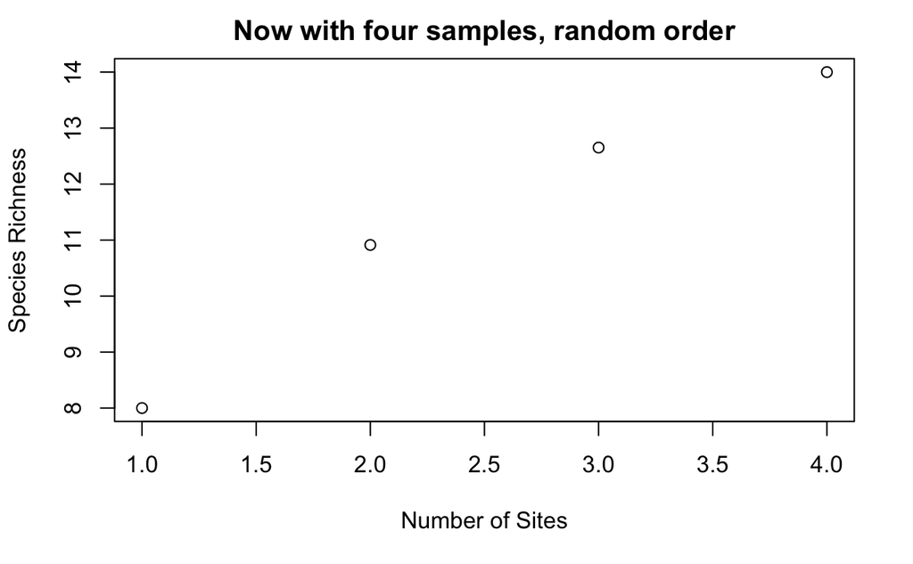

```r
plot(accurve$sites, accurve$richness,
     xlab="Number of Sites",
     ylab="Species Richness",
     main="Now with four samples, random order")
```

[figure not shown]

```r
accurve2<-specaccum(abundance, method="collector", permutations=100)
plot(accurve2$sites, accurve$richness,
     xlab="Number of Sites",
     ylab="Species Richness",
     main="As encountered, with four samples")
```